# **Is Beauty Really Subjective?**

**By Shiv Medler, Luke Luo, Kevin Tang and approved by Professor Morawski**

# **Motivation**

[Project Code](https://ktang124.github.io/320code.ipynb)

Humans can recognize beauty instantly, even babies see beauty. However, it is difficult to identify what specifically makes someone beautiful or not beautiful. Why are some features desirable but others are not? We know that there are subjective preferences rooted in culture. Some may generalize these preferences into western and eastern beauty standards. For this project, we will try to see if there are any universal features of beauty.

One data source that we can use for this study is the Chicago Face Database. This database is a folder that contains about 600 images of faces from the United States. These faces include men and women of white, latin, asian, and black descent. For each of these faces, there are corresponding measurements of different attributes of the face alongside subjective ratings of the face based on a U.S. voter sample. We will do regression on the attribute measurements and deep learning on the face images to see if the machine can find variables that explain the variation in the subjective ratings of the faces. If these kinds of variables exist, then we know that there are objective factors to beauty.

One application of this study lies in the face's ability to indicate the health of the individual. Features like acne are unattractive because irregularities in skin usually indicate disease like smallpox or chickenpox. Some features indicate underlying conditions like fetal alcohol syndrome, whose characteristics can be recognized in children. The idea that attractiveness implies health and unattractiveness implies lack of health lends itself to an application for the beauty algorithm. It could be used to detect certain features that suggest diseases and conditions early on.

Furthermore, we know that beauty measurement algorithms are prevalent in today's social media apps, particularly tiktok, where more attractive content creators are pushed to users' recommendations. Nonetheless, these algorithms are used because they attract users' attention. More attention drives more ad revenue, more ad revenue drives more profits for social media companies. The beauty algorithm is just one tool used in recommendation systems. Therefore, through our dataset, we can gain insight into these systems.

# Part 1: Linear Regression

##### **Method**

In this part, we will be analyzing the objectivity of beauty by doing linear regression of the facial measurements in the Chicago Face Database. This regression will be done using the statsmodel ordinary least squares method. The method finds the line of best fit by finding a line that minimizes the squared error. More information on the statsmodel OLS linear regression method can be found in this [journal](https://medium.com/analytics-vidhya/application-and-interpretation-with-ols-statsmodels-499c69ef6834).

##### **Data Collection/Storage**

The data for the subjective ratings of beauty and the facial measurements are all present in the folder excel file. The sheet for the dataset that we are working with is called CFD U.S. Norming Data. A picture of the sheet is shown in the link below:

[Data Image](https://drive.google.com/file/d/1fb9Z0SAHQckywBdWzy4p40wqEEUwgFMC/view?usp=share_link)

The goal is to use the pandas read_excel method to store the data as a pandas dataframe. The issue is that the method would also read in the grey description which is data that we do not want. To fix this, we can remove the grey space such that we only read the data we want. The resulting excel file would look like this:

[New Excel File](https://drive.google.com/file/d/1rx0773p_YGgC9ws0lTwtWA1mDwffIXAQ/view?usp=share_link)

```python
import pandas as pd
import numpy as np
from statsmodels.stats.outliers_influence import variance_inflation_factor
from statsmodels.tools.tools import add_constant
import statsmodels.api as sm
import statsmodels.formula.api as smf
import numpy as np
import seaborn as sns
import matplotlib.pyplot as plt
from statsmodels.graphics.gofplots import ProbPlot
```

```python
#The data can now be read by the pandas read_excel method in which this method is run and the first few rows of the dataframe are outputted below.
face_df = pd.read_excel('cfd/CFD Version 3.0/CFD 3.0 Norming Data and Codebook.xlsx', sheet_name='CFD U.S. Norming Data')
face_df.head()
```

|  | Model | EthnicitySelf | GenderSelf | AgeSelf | AgeRated | Unnamed: 5 | FemaleProb | MaleProb | AsianProb | ChineseAsianProb | ... | Unnamed: 141 | Unnamed: 142 | Unnamed: 143 | Unnamed: 144 | Unnamed: 145 | Unnamed: 146 | Unnamed: 147 | Unnamed: 148 | Unnamed: 149 | Unnamed: 150 |
| --- | --- | --- | --- | --- | --- | --- | --- | --- | --- | --- | --- | --- | --- | --- | --- | --- | --- | --- | --- | --- | --- |
| 0 | NaN | NaN | NaN | NaN | R002_mean | R002_sd | NaN | NaN | NaN | NaN | ... | NaN | NaN | NaN | NaN | NaN | NaN | NaN | NaN | NaN | NaN |
| 1 | AF-200 | A | F | NaN | 32.571429 | NaN | 1.000000 | 0.000000 | 1.000000 | NaN | ... | NaN | NaN | NaN | NaN | NaN | NaN | NaN | NaN | NaN | NaN |
| 2 | AF-201 | A | F | NaN | 23.666667 | NaN | 1.000000 | 0.000000 | 0.962963 | NaN | ... | NaN | NaN | NaN | NaN | NaN | NaN | NaN | NaN | NaN | NaN |
| 3 | AF-202 | A | F | NaN | 24.448276 | NaN | 0.827586 | 0.172414 | 0.310345 | NaN | ... | NaN | NaN | NaN | NaN | NaN | NaN | NaN | NaN | NaN | NaN |
| 4 | AF-203 | A | F | NaN | 22.758621 | NaN | 1.000000 | 0.000000 | 0.758621 | NaN | ... | NaN | NaN | NaN | NaN | NaN | NaN | NaN | NaN | NaN | NaN |

5 rows × 151 columns

The issue now is with the column names since the names of the columns were distributed across two rows. This leaves us with three distinct possibilites:

1. The column name is only present in the dataframe column name and the first row of that column is marked as not a number.
2. The actual column name is present in the first row of the column and the column name in the dataframe.
3. The pandas dataframe column name is marked as unnamed while the actual name is in the first row of the column data.

```python
#In the code below, qw renamed the pandas dataframe taking into account these three cases. We did this by creating the new_names dictionary and iterating
#through the column name and data in the dataframe using the pandas iteritems method. This is because the pandas rename takes in a dictionary with the old
#names being assigned to the new ones. For the first case, we kept the old name. With the second case, we concantenated the name and the string value for
#the first row in the column. For the third case, we set the new column to the first row of the column. The result of this renaming is shown below.
new_names = {}

for (columnName, columnData) in face_df.iteritems():
  if pd.isna(columnData[0]):
    new_names[columnName] = columnName
  else:
    if columnName.split(":")[0] == "Unnamed":
      new_names[columnName] = columnData[0]
    else:
      new_names[columnName] = columnName + " " + str(columnData[0])

face_df = face_df.rename(columns = new_names)
face_df.head()
```

|  | Model | EthnicitySelf | GenderSelf | AgeSelf | AgeRated R002_mean | R002_sd | FemaleProb | MaleProb | AsianProb | ChineseAsianProb | ... | Unnamed: 141 | Unnamed: 142 | Unnamed: 143 | Unnamed: 144 | Unnamed: 145 | Unnamed: 146 | Unnamed: 147 | Unnamed: 148 | Unnamed: 149 | Unnamed: 150 |
| --- | --- | --- | --- | --- | --- | --- | --- | --- | --- | --- | --- | --- | --- | --- | --- | --- | --- | --- | --- | --- | --- |
| 0 | NaN | NaN | NaN | NaN | R002_mean | R002_sd | NaN | NaN | NaN | NaN | ... | NaN | NaN | NaN | NaN | NaN | NaN | NaN | NaN | NaN | NaN |
| 1 | AF-200 | A | F | NaN | 32.571429 | NaN | 1.000000 | 0.000000 | 1.000000 | NaN | ... | NaN | NaN | NaN | NaN | NaN | NaN | NaN | NaN | NaN | NaN |
| 2 | AF-201 | A | F | NaN | 23.666667 | NaN | 1.000000 | 0.000000 | 0.962963 | NaN | ... | NaN | NaN | NaN | NaN | NaN | NaN | NaN | NaN | NaN | NaN |
| 3 | AF-202 | A | F | NaN | 24.448276 | NaN | 0.827586 | 0.172414 | 0.310345 | NaN | ... | NaN | NaN | NaN | NaN | NaN | NaN | NaN | NaN | NaN | NaN |
| 4 | AF-203 | A | F | NaN | 22.758621 | NaN | 1.000000 | 0.000000 | 0.758621 | NaN | ... | NaN | NaN | NaN | NaN | NaN | NaN | NaN | NaN | NaN | NaN |

5 rows × 151 columns

```python
#Since the concantenation was done for data in the first row that was a part of a column name, the first row would no longer be needed. Thus, in the code
#below, the first row is removed and the resulting dataframe is shown below.
face_df = face_df.iloc[1:, :]
face_df.head()
```

|  | Model | EthnicitySelf | GenderSelf | AgeSelf | AgeRated R002_mean | R002_sd | FemaleProb | MaleProb | AsianProb | ChineseAsianProb | ... | Unnamed: 141 | Unnamed: 142 | Unnamed: 143 | Unnamed: 144 | Unnamed: 145 | Unnamed: 146 | Unnamed: 147 | Unnamed: 148 | Unnamed: 149 | Unnamed: 150 |
| --- | --- | --- | --- | --- | --- | --- | --- | --- | --- | --- | --- | --- | --- | --- | --- | --- | --- | --- | --- | --- | --- |
| 1 | AF-200 | A | F | NaN | 32.571429 | NaN | 1.000000 | 0.000000 | 1.000000 | NaN | ... | NaN | NaN | NaN | NaN | NaN | NaN | NaN | NaN | NaN | NaN |
| 2 | AF-201 | A | F | NaN | 23.666667 | NaN | 1.000000 | 0.000000 | 0.962963 | NaN | ... | NaN | NaN | NaN | NaN | NaN | NaN | NaN | NaN | NaN | NaN |
| 3 | AF-202 | A | F | NaN | 24.448276 | NaN | 0.827586 | 0.172414 | 0.310345 | NaN | ... | NaN | NaN | NaN | NaN | NaN | NaN | NaN | NaN | NaN | NaN |
| 4 | AF-203 | A | F | NaN | 22.758621 | NaN | 1.000000 | 0.000000 | 0.758621 | NaN | ... | NaN | NaN | NaN | NaN | NaN | NaN | NaN | NaN | NaN | NaN |
| 5 | AF-204 | A | F | NaN | 30.137931 | NaN | 1.000000 | 0.000000 | 0.827586 | NaN | ... | NaN | NaN | NaN | NaN | NaN | NaN | NaN | NaN | NaN | NaN |

5 rows × 151 columns

Some of the columns have no data associated with it in which all the values are marked as NaN. Hence, we can safely remove these columns without affecting our data analysis. However, this does mean that we will be unable to make certain insights about our data. An example would be how a person's self-identified age affects beauty and the variation in the measured ratings for each of the faces since the AgeSelf and standard deviations for the rated columns would all be removed in this step since they have no data.

```python
#The pandas dropna method can be used to remove the columns where all the data is NaN. The code and corresponding output is shown below.
face_df = face_df.dropna(axis = 1, how='all')
face_df.head()
```

|  | Model | EthnicitySelf | GenderSelf | AgeRated R002_mean | FemaleProb | MaleProb | AsianProb | BlackProb | LatinoProb | MultiProb | ... | EyeSize | UpperHeadLength | MidfaceLength | ChinLength | ForeheadHeight | CheekboneHeight | CheekboneProminence | FaceRoundness | fWHR2 | RaterN |
| --- | --- | --- | --- | --- | --- | --- | --- | --- | --- | --- | --- | --- | --- | --- | --- | --- | --- | --- | --- | --- | --- |
| 1 | AF-200 | A | F | 32.571429 | 1.000000 | 0.000000 | 1.000000 | 0.000000 | 0.000000 | 0.000000 | ... | 0.060924 | 0.414099 | 0.326797 | 0.130719 | 0.264706 | 0.388189 | 91.5 | 0.545752 | 1.973890 | 28.0 |
| 2 | AF-201 | A | F | 23.666667 | 1.000000 | 0.000000 | 0.962963 | 0.000000 | 0.000000 | 0.037037 | ... | 0.041892 | 0.414414 | 0.329279 | 0.144595 | 0.300901 | 0.383784 | 146.0 | 0.488288 | 2.068681 | 27.0 |
| 3 | AF-202 | A | F | 24.448276 | 0.827586 | 0.172414 | 0.310345 | 0.068966 | 0.137931 | 0.448276 | ... | 0.051586 | 0.411080 | 0.310317 | 0.173424 | 0.298475 | 0.397029 | 58.0 | 0.481333 | 1.987261 | 29.0 |
| 4 | AF-203 | A | F | 22.758621 | 1.000000 | 0.000000 | 0.758621 | 0.000000 | 0.068966 | 0.172414 | ... | 0.063913 | 0.354407 | 0.343793 | 0.169820 | 0.272266 | 0.421089 | 87.5 | 0.500231 | 1.902284 | 29.0 |
| 5 | AF-204 | A | F | 30.137931 | 1.000000 | 0.000000 | 0.827586 | 0.000000 | 0.068966 | 0.103448 | ... | 0.053435 | 0.438931 | 0.293045 | 0.180237 | 0.293893 | 0.371925 | 73.5 | 0.513571 | 2.081081 | 29.0 |

5 rows × 73 columns

The variables that are left over is presented below where each of the column names are printed out. For further information on what all of these values measure and the way that this data is collected, you can look up each of the column names on the google sheet below. This google sheet is from the Chicago Face Database and gives these details for all of the variables present in the database. In general, the self-reported measures refer to the individuals' identity characteristes, the rated measures refer to how a U.S. sample group perceive the individuals, and the physical attributes are different measurements of the individuals' face.

[Lookup Table](https://docs.google.com/spreadsheets/d/1_gwt0IQAA0sHaD2lslVT8sqmrWrUNQ3Y/edit?usp=sharing&ouid=100378183883690687989&rtpof=true&sd=true)

```python
for col in face_df.columns:
    print(col)
```

```
Model
EthnicitySelf
GenderSelf
AgeRated R002_mean
FemaleProb
MaleProb
AsianProb
BlackProb
LatinoProb
MultiProb
OtherProb
WhiteProb
Afraid R011_mean
Angry R012_mean
Attractive R013_mean
Babyfaced R014_mean
Disgusted R015_mean
Dominant R016_mean
Feminine R017_mean
Happy R018_mean
Masculine R019_mean
Prototypic R020_mean
Sad R021_mean
Suitability R022_mean
Surprised R023_mean
Threatening R024_mean
Trustworthy R025_mean
Unusual R026_mean
LuminanceMedian
NoseWidth
NoseLength
LipThickness
FaceLength
EyeHeightR
EyeHeightL
EyeHeightAvg
EyeWidthR
EyeWidthL
EyeWidthAvg
FaceWidthCheeks
```

[output cut: 18 more lines]

```
FaceShape
Heartshapeness
NoseShape
LipFullness
EyeShape
EyeSize
UpperHeadLength
MidfaceLength
ChinLength
ForeheadHeight
CheekboneHeight
CheekboneProminence
FaceRoundness
fWHR2
RaterN
```

##### **Variable Selection**

For the purposes of this project, we will be focusing on how the measured attributes of the peoples' faces would affect whether people would view them as attractive. Hence, in accordance to the lookup table, we would first look for the column labels that have a corresponding VarID that begins with P. These will be our predictors. Then, we will use Attractive R013_mean as the response variable. The variables measures on average, from a scale of 1-7, how a sample of Americans rated a face as attractive.

The major measurements we lose from selecting the predictors in this way would be the perceptions of the people rating the faces in terms of attractiveness. An example would be the perception of race and gender of a given face for the people rating the face. However, since we are focusing on the unconscious features that people can focus on in assessing a person's beauty, we are not going to look at these features that people were consciously thinking about when assessing the face's attractiveness. Another measurement we would not include would be the size of the sample of people that rated the faces' attractiveness. This is because we believe that these sample sizes were roughly the same in which this information would not be useful in describing the variation for attractiveness. Finally, we are also not looking at the gender and race of the individual since according to the description of Attractive R013-mean, the participants were asked to rate people's face with respect to other people of the same race and gender. Hence, these two variables were controlled for in the data collection process.

To remove the unwanted variables, we used the lookup table shown before in which we intended to use the column's associated VarID in deciding to delete them. Model was removed since it had no corresponding VarID in the table and was not needed since it only stored the filename for a given photo. Before we dropped the columns, however, we sectioned out the Model and Attractiveness columns of the dataframe for the deep learning part of the project.

```python
deep_df = face_df[["Model", "Attractive R013_mean"]]

face_df = face_df.drop(["Model"], axis = 1)
dropped_columns = []
```

```python
#Similar to creating the face dataframe, we first removed the grey description in excel before using the read_excel method to read the data.
lookup_table = pd.read_excel('cfd/CFD Version 3.0/CFD 3.0 Norming Data and Codebook.xlsx', sheet_name='CFD 3.0 Codebook')
lookup_table.head()
```

|  | CFD | CFD-MR | CFD-I | VarID | VarLabel | Description | Unnamed: 6 | Unnamed: 7 |
| --- | --- | --- | --- | --- | --- | --- | --- | --- |
| 0 | x | x | x | NaN | Model | Model ID - first character designates self-rep... | NaN | NaN |
| 1 | x | x | x | S001 | EthnicitySelf | Model ethnicity, self-reported | NaN | NaN |
| 2 | x | x | x | S002 | GenderSelf | Model gender, self-reported | NaN | NaN |
| 3 | NaN | x | x | S003 | AgeSelf | Age, self-reported | NaN | NaN |
| 4 | x | x | x | R002 | AgeRated | Estimate the approximate age of this person (i... | NaN | NaN |

```python
#After putting the lookup_table into a pandas dataframe, we iterated through all of the columns in the face dataframe. We extracted the first word for each
#of the column names such that it can match up with the label listed in the lookup table. We then filtered the dataframe to include the entries that had
#this label as VarLabel. Multiple entries may be returned in this case, but we knew that they would all start with the same letter for the VarID. Hence, we
#only needed to look at the first entry. If the first letter for the VarID was R and the variable was not the Attractive measure, we would remove it since
#we are only looking at the Attractive subjective measure. The columns to be removed were stored in the dropped_columns list and removed by the pandas
#dropped method.
for col in face_df.columns:
  col_name = col.split(" ")[0]
  lookup_row = lookup_table.loc[lookup_table["VarLabel"] == col_name]
  label = lookup_row.iloc[0]["VarID"]

  if label[0] == "R" or label[0] == "S":
    if col != "Attractive R013_mean":
      dropped_columns.append(col)
```

List of columns to be dropped in which it includes the sample number for the image ratings and all of the other subjective ratings besides attractiveness.

```python
dropped_columns
```

```
['EthnicitySelf',
 'GenderSelf',
 'AgeRated R002_mean',
 'FemaleProb',
 'MaleProb',
 'AsianProb',
 'BlackProb',
 'LatinoProb',
 'MultiProb',
 'OtherProb',
 'WhiteProb',
 'Afraid R011_mean',
 'Angry R012_mean',
 'Babyfaced R014_mean',
 'Disgusted R015_mean',
 'Dominant R016_mean',
 'Feminine R017_mean',
 'Happy R018_mean',
 'Masculine R019_mean',
 'Prototypic R020_mean',
 'Sad R021_mean',
 'Suitability R022_mean',
 'Surprised R023_mean',
 'Threatening R024_mean',
 'Trustworthy R025_mean',
 'Unusual R026_mean',
 'RaterN']
```

```python
#The columns in the dropped_columns list are removed and the resulting dataframe is printed.
face_df = face_df.drop(dropped_columns, axis = 1)
face_df.head()
```

|  | Attractive R013_mean | LuminanceMedian | NoseWidth | NoseLength | LipThickness | FaceLength | EyeHeightR | EyeHeightL | EyeHeightAvg | EyeWidthR | ... | EyeShape | EyeSize | UpperHeadLength | MidfaceLength | ChinLength | ForeheadHeight | CheekboneHeight | CheekboneProminence | FaceRoundness | fWHR2 |
| --- | --- | --- | --- | --- | --- | --- | --- | --- | --- | --- | --- | --- | --- | --- | --- | --- | --- | --- | --- | --- | --- |
| 1 | 4.111111 | 174.0 | 230.5 | 250.5 | 135.5 | 1071.0 | 63.5 | 67.0 | 65.25 | 163.0 | ... | 0.404651 | 0.060924 | 0.414099 | 0.326797 | 0.130719 | 0.264706 | 0.388189 | 91.5 | 0.545752 | 1.973890 |
| 2 | 3.111111 | 172.0 | 233.5 | 235.0 | 129.0 | 1110.0 | 44.0 | 49.0 | 46.50 | 144.0 | ... | 0.329204 | 0.041892 | 0.414414 | 0.329279 | 0.144595 | 0.300901 | 0.383784 | 146.0 | 0.488288 | 2.068681 |
| 3 | 3 | 153.5 | 277.5 | 268.0 | 141.5 | 1245.5 | 66.5 | 62.0 | 64.25 | 177.0 | ... | 0.357939 | 0.051586 | 0.411080 | 0.310317 | 0.173424 | 0.298475 | 0.397029 | 58.0 | 0.481333 | 1.987261 |
| 4 | 3.275862 | 175.5 | 233.5 | 240.0 | 129.5 | 1083.5 | 68.0 | 70.5 | 69.25 | 155.0 | ... | 0.443200 | 0.063913 | 0.354407 | 0.343793 | 0.169820 | 0.272266 | 0.421089 | 87.5 | 0.500231 | 1.902284 |
| 5 | 3.172414 | 168.5 | 252.5 | 257.5 | 100.0 | 1179.0 | 66.0 | 60.0 | 63.00 | 150.0 | ... | 0.432247 | 0.053435 | 0.438931 | 0.293045 | 0.180237 | 0.293893 | 0.371925 | 73.5 | 0.513571 | 2.081081 |

5 rows × 45 columns

The remaining predictor variables:

```python
for col in face_df.columns:
    print(col)
```

```
Attractive R013_mean
LuminanceMedian
NoseWidth
NoseLength
LipThickness
FaceLength
EyeHeightR
EyeHeightL
EyeHeightAvg
EyeWidthR
EyeWidthL
EyeWidthAvg
FaceWidthCheeks
FaceWidthMouth
FaceWidthBZ
Forehead
UpperFaceLength2
PupilTopR
PupilTopL
PupilTopAsymmetry
PupilLipR
PupilLipL
PupilLipAvg
PupilLipAsymmetry
BottomLipChin
MidcheekChinR
MidcheekChinL
CheeksAvg
MidbrowHairlineR
MidbrowHairlineL
MidbrowHairlineAvg
FaceShape
Heartshapeness
NoseShape
LipFullness
EyeShape
EyeSize
UpperHeadLength
MidfaceLength
ChinLength
ForeheadHeight
CheekboneHeight
CheekboneProminence
FaceRoundness
fWHR2
```

##### **Addressing Multicollinearity**

One issue that is present with these variables is multicollinearity. This is where the predictor variables are correlated with each other. This can cause high variance in the estimated coefficients for these variables and lead to misleading interpretations of the regression results. As seen with the column names, there are variables like the measurements of the eye width and height that would seem to be correlated. To see if any of the variables cause this issue, we would look at the Variance Influence Factor values for them. These values are calculated for each predictor by seeing how much of the variation in this predictor is explained by the rest of these predictors.

More information on Multicollinearity and VIF is explained in this [link](https://towardsdatascience.com/everything-you-need-to-know-about-multicollinearity-2f21f082d6dc).

```python
#X_variables holds all the measurement predictors for the model which is why the Attractive variable was dropped to form it.
X_variables = face_df.drop(['Attractive R013_mean'],axis=1)
```

```python
#For the calculate_vif function, the add_constant method from statsmodels is first used since when fitting the linear regression, we plan to include a
#constant term such that the line can better fit the data. Then, a new dataframe is created in which the feature column would hold the column names while
#the VIF column would hold the corresponding VIF values. The VIF was calculated by using the variance_inflation_factor method from statsmodel which takes
#in a dataset of explanatory variables and an index to calculate a VIF value for a given variable. In the code below, this value is calculate for all the
#indices in the column and stored in a list. This list is then used as the column data for the VIF column. The resulting dataframe is then returned.
def calculate_vif(X):
  X = add_constant(X)
  vif_data = pd.DataFrame()
  vif_data["feature"] = X.columns
  vif_data["VIF"] = [variance_inflation_factor(X.values, i) for i in range(len(X.columns))]
  return vif_data
```

```python
calculate_vif(X_variables)
```

|  | feature | VIF |
| --- | --- | --- |
| 0 | const | 1.580107e+06 |
| 1 | LuminanceMedian | 3.048347e+00 |
| 2 | NoseWidth | 4.022831e+01 |
| 3 | NoseLength | 4.040575e+01 |
| 4 | LipThickness | 1.544772e+03 |
| 5 | FaceLength | 5.408425e+03 |
| 6 | EyeHeightR | 2.930570e+03 |
| 7 | EyeHeightL | 3.041537e+03 |
| 8 | EyeHeightAvg | 1.203772e+04 |
| 9 | EyeWidthR | inf |
| 10 | EyeWidthL | inf |
| 11 | EyeWidthAvg | inf |
| 12 | FaceWidthCheeks | 6.412280e+02 |
| 13 | FaceWidthMouth | 1.360831e+03 |
| 14 | FaceWidthBZ | 5.418569e+01 |
| 15 | Forehead | 2.610384e+03 |
| 16 | UpperFaceLength2 | 1.614266e+02 |
| 17 | PupilTopR | 1.577170e+01 |
| 18 | PupilTopL | 1.779202e+01 |
| 19 | PupilTopAsymmetry | 1.178832e+00 |
| 20 | PupilLipR | inf |
| 21 | PupilLipL | inf |
| 22 | PupilLipAvg | inf |
| 23 | PupilLipAsymmetry | 1.118669e+00 |
| 24 | BottomLipChin | 1.691301e+03 |
| 25 | MidcheekChinR | inf |
| 26 | MidcheekChinL | inf |
| 27 | CheeksAvg | inf |
| 28 | MidbrowHairlineR | inf |
| 29 | MidbrowHairlineL | inf |
| 30 | MidbrowHairlineAvg | inf |
| 31 | FaceShape | 1.425500e+03 |
| 32 | Heartshapeness | 1.205149e+02 |
| 33 | NoseShape | 8.655009e+01 |
| 34 | LipFullness | 1.445195e+03 |
| 35 | EyeShape | 2.362053e+02 |
| 36 | EyeSize | 4.428415e+02 |
| 37 | UpperHeadLength | 1.256847e+03 |
| 38 | MidfaceLength | 1.233559e+03 |
| 39 | ChinLength | 1.532361e+03 |
| 40 | ForeheadHeight | 4.031499e+02 |
| 41 | CheekboneHeight | 1.012777e+03 |
| 42 | CheekboneProminence | 1.028709e+01 |
| 43 | FaceRoundness | 1.878026e+03 |
| 44 | fWHR2 | 1.294276e+02 |

In the code below, we are finding the explanatory variables that will be used to predict attractiveness taking into account multicollinearity.

```python
#To select the variables, we iterated through the columns and appending each variable to the final columns list. A local dataframe is constructed with the
#new_df variable by specifying the variables in this list when accessing the X_variables dataframe. When a new variable is added, if this causes one of the
#variables to have a VIF value of over 10, then this variable is removed and will not be a part of the final_columns list. In the VIF value condition, iloc
#is used since we will only look at the VIF values for the explanatory variables rather than including the constant. The final_columns list is then
#outputted and shows the columns that were able to be included in the model without having one of the explanatory values have a VIF value above 10.
final_columns = []
for col in X_variables.columns:
  final_columns.append(col)
  new_df = X_variables[final_columns]
  vif_results = calculate_vif(new_df)

  if vif_results["VIF"].iloc[1:].max() > 10:
    final_columns.remove(col)

final_columns
```

```
['LuminanceMedian',
 'NoseWidth',
 'NoseLength',
 'LipThickness',
 'FaceLength',
 'EyeHeightR',
 'EyeHeightL',
 'EyeWidthR',
 'EyeWidthL',
 'FaceWidthCheeks',
 'FaceWidthMouth',
 'FaceWidthBZ',
 'Forehead',
 'UpperFaceLength2',
 'PupilTopR',
 'PupilTopAsymmetry',
 'PupilLipR',
 'PupilLipAsymmetry',
 'MidbrowHairlineR',
 'MidbrowHairlineL',
 'CheekboneHeight',
 'CheekboneProminence']
```

To set up the data analysis, the X variable is set to the face dataframe that includes the columns in final_columns while the y variable is set to the response of the subjective attractive values. As shown by the output, when calculating the VIF values for these predictors, none of these values went above 10 which shows that multicollinearity is not an issue when using these predictors for the regression.

```python
X = X_variables[final_columns]
y = face_df['Attractive R013_mean']
calculate_vif(add_constant(X))
```

|  | feature | VIF |
| --- | --- | --- |
| 0 | const | 2604.688971 |
| 1 | LuminanceMedian | 2.886387 |
| 2 | NoseWidth | 2.526397 |
| 3 | NoseLength | 3.276837 |
| 4 | LipThickness | 2.330602 |
| 5 | FaceLength | 7.876993 |
| 6 | EyeHeightR | 6.294015 |
| 7 | EyeHeightL | 6.499980 |
| 8 | EyeWidthR | 6.048317 |
| 9 | EyeWidthL | 6.101242 |
| 10 | FaceWidthCheeks | 2.934830 |
| 11 | FaceWidthMouth | 6.374114 |
| 12 | FaceWidthBZ | 2.779433 |
| 13 | Forehead | 5.389834 |
| 14 | UpperFaceLength2 | 4.869281 |
| 15 | PupilTopR | 8.013258 |
| 16 | PupilTopAsymmetry | 1.096137 |
| 17 | PupilLipR | 5.772186 |
| 18 | PupilLipAsymmetry | 1.075767 |
| 19 | MidbrowHairlineR | 7.728577 |
| 20 | MidbrowHairlineL | 6.777467 |
| 21 | CheekboneHeight | 3.933899 |
| 22 | CheekboneProminence | 6.944041 |

##### **Fitting Model/Exploratory Data Analysis**

In this code below, we fit the selected variables above into the statsmodel ordinary least squares linear model and then printed out the summart of this model. Looking at the R-squared in the summary, we can see that our facial measurement predictors explain 24.2% of the variation in the attractiveness ratings. For real world data, this is a promising result suggesting that the facial measurements that we looked at had an influence on how the different groups rated a face in terms of attractiveness. More information on R-squares is shown [here](https://towardsdatascience.com/demystifying-r-squared-and-adjusted-r-squared-52903c006a60).

```python
#Both the predictor and explanatory variable dataframe columns are all converted into floats such that they can be used in the statsmodel OLS method.
#A constant is added to the X_model variable since we want to use a constant term in the equation to better fit the attractiveness data points.
X_model = X.astype(float)
y_model = y.astype(float)
X_model = sm.add_constant(X_model)

model = sm.OLS(y_model, X_model)
res = model.fit()
res.summary()
```

OLS Regression Results

| Dep. Variable: | Attractive R013_mean | R-squared: | 0.242 |
| --- | --- | --- | --- |
| Model: | OLS | Adj. R-squared: | 0.213 |
| Method: | Least Squares | F-statistic: | 8.313 |
| Date: | Thu, 15 Dec 2022 | Prob (F-statistic): | 3.22e-23 |
| Time: | 22:43:31 | Log-Likelihood: | -607.00 |
| No. Observations: | 597 | AIC: | 1260. |
| Df Residuals: | 574 | BIC: | 1361. |
| Df Model: | 22 |  |  |
| Covariance Type: | nonrobust |  |  |

|  | coef | std err | t | P>\|t\| | [0.025 | 0.975] |
| --- | --- | --- | --- | --- | --- | --- |
| const | -2.8223 | 1.425 | -1.981 | 0.048 | -5.621 | -0.024 |
| LuminanceMedian | 0.0048 | 0.002 | 2.990 | 0.003 | 0.002 | 0.008 |
| NoseWidth | 0.0034 | 0.002 | 1.981 | 0.048 | 2.85e-05 | 0.007 |
| NoseLength | 0.0082 | 0.002 | 4.241 | 0.000 | 0.004 | 0.012 |
| LipThickness | 0.0060 | 0.002 | 3.636 | 0.000 | 0.003 | 0.009 |
| FaceLength | -0.0066 | 0.001 | -5.822 | 0.000 | -0.009 | -0.004 |
| EyeHeightR | -0.0001 | 0.008 | -0.013 | 0.990 | -0.017 | 0.016 |
| EyeHeightL | 0.0083 | 0.008 | 0.992 | 0.322 | -0.008 | 0.025 |
| EyeWidthR | 0.0002 | 0.006 | 0.038 | 0.970 | -0.012 | 0.012 |
| EyeWidthL | 0.0044 | 0.006 | 0.692 | 0.489 | -0.008 | 0.017 |
| FaceWidthCheeks | -0.0032 | 0.001 | -2.221 | 0.027 | -0.006 | -0.000 |
| FaceWidthMouth | 0.0008 | 0.001 | 0.587 | 0.558 | -0.002 | 0.004 |
| FaceWidthBZ | 0.0007 | 0.001 | 0.499 | 0.618 | -0.002 | 0.003 |
| Forehead | 0.0048 | 0.001 | 3.436 | 0.001 | 0.002 | 0.008 |
| UpperFaceLength2 | 0.0063 | 0.002 | 3.327 | 0.001 | 0.003 | 0.010 |
| PupilTopR | 0.0076 | 0.002 | 4.140 | 0.000 | 0.004 | 0.011 |
| PupilTopAsymmetry | 0.0038 | 0.003 | 1.470 | 0.142 | -0.001 | 0.009 |
| PupilLipR | -0.0020 | 0.002 | -0.856 | 0.392 | -0.007 | 0.003 |
| PupilLipAsymmetry | -0.0149 | 0.007 | -2.261 | 0.024 | -0.028 | -0.002 |
| MidbrowHairlineR | -0.0020 | 0.002 | -1.044 | 0.297 | -0.006 | 0.002 |
| MidbrowHairlineL | -0.0010 | 0.002 | -0.593 | 0.554 | -0.004 | 0.002 |
| CheekboneHeight | 7.5613 | 2.158 | 3.504 | 0.000 | 3.323 | 11.799 |
| CheekboneProminence | 0.0006 | 0.001 | 0.519 | 0.604 | -0.002 | 0.003 |

| Omnibus: | 9.468 | Durbin-Watson: | 1.867 |
| --- | --- | --- | --- |
| Prob(Omnibus): | 0.009 | Jarque-Bera (JB): | 9.171 |
| Skew: | 0.267 | Prob(JB): | 0.0102 |
| Kurtosis: | 2.712 | Cond. No. | 1.66e+05 |

Notes:  
[1] Standard Errors assume that the covariance matrix of the errors is correctly specified.  
[2] The condition number is large, 1.66e+05. This might indicate that there are  
strong multicollinearity or other numerical problems.

As part of the analysis for the linear regression model, we would need to check whether our model meets the assumptions of a linear model. These assumptions include that the errors in the model are normally distributed, independent, have an average of zero (linearity assumption), and have a constant variance. If any of these assumptions are violated, then variable transformation may be needed. The assumptions need to be met such that more valid conclusions can be drawn from the results of the linear model. A fifth assumption is that there is no multicollinearity among the predictors, but we have already addressed this in a previous step. More information about a linear model's assumptions is in this [link](https://www.statisticssolutions.com/free-resources/directory-of-statistical-analyses/assumptions-of-linear-regression/).

We can check the indepedence, normality, and averages of the error assumption by looking at the residuals vs fitted values scatterplot.

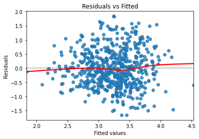

```python
# We got the fitted values from the fittedvalues attribute in the model results.
# Then, we inputted the fitted values and actual values into the seaborn
# residplot method and had a red line drawn on the graph to represent the
# average of the residuals at each section of the graph. This was to check
# whether the average values of the residuals are approximately zero.
fitted_y = res.fittedvalues

res_plot = plt.figure()
sns.residplot(fitted_y, y, lowess = True, line_kws={'color': 'red'})
res_plot.axes[0].set_title('Residuals vs Fitted')
res_plot.axes[0].set_xlabel('Fitted values')
res_plot.axes[0].set_ylabel('Residuals');
```

We can observe that the residuals are spread out around the line with points being concentrated at the line such that the average of the residuals is zero. This signals that there is a linear relationship in terms of the attractiveness ratings in which the linearity assumption would be satisfied. We can also use the residual graph as evidence that the residuals are independent from each other. This is because there is no clear pattern that can be established with the residuals. The residuals also support the homoscedasticity (constant variance) assumption since they are evenly distributed across the graph.

We can check the normality assumption by looking at the Normal Q-Q plot. In this type of plot, if the standardized residuals are placed approximately on the 45 degree angle line, then we would know that the residuals are distributed normally in which this assumption would be met. More information on the Normal Q-Q plot is given in this [link](https://data.library.virginia.edu/understanding-q-q-plots/).

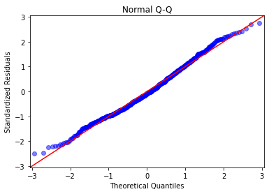

```python
# The standardized residuals are gathered from the model results in statsmodel.
# The model results are stored in the variable res. Then, in statsmodel, the
# ProbPlot takes in these standardized residuals and produces the QQ plot. We
# then set the labels and the 45 degree line to appear on the graph such that
# we could see how well the points would fit on that line.
norm_residuals = res.get_influence().resid_studentized_internal

QQ = ProbPlot(norm_residuals)
plot_lm_2 = QQ.qqplot(line='45', alpha=0.5, color='b', lw=1)
plot_lm_2.axes[0].set_title('Normal Q-Q')
plot_lm_2.axes[0].set_xlabel('Theoretical Quantiles')
plot_lm_2.axes[0].set_ylabel('Standardized Residuals');
```

The QQ plot places points close to the 45 degree line, which suggests that the errors are distributed approximately normal such that the normality of the error assumption would be met. This assumption can be further checked by looking at the histogram of the model.

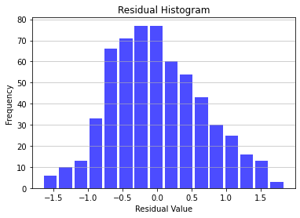

```python
# The histogram is made using the hist method in pyplot in which the model
# residuals is input into the function and the correspoding labels are made.
# The residuals of the model are gathered through the resid attribute in the
# model results. The labels for the histogram are then set.
residuals = res.resid
plt.hist(x=residuals, bins='auto', color='b',
                           alpha=0.7, rwidth=0.85)
plt.grid(axis='y', alpha=0.75)
plt.xlabel('Residual Value')
plt.ylabel('Frequency')
plt.title('Residual Histogram')
```

The shape of the histogram is approximately a normal bell curve which further supports the results of the Q-Q plot in showing that the errors being normally distributed assumption is met by this model.

With the assumptions of the model met, no transformations of the variables are needed in which we are able to draw conclusions from the results of the linear model. To analyze the specific ways in which the predictors impact the attractiveness ratings, we can look at the scatterplots for the most significant features.

```python
#This is a function that takes in a feature and returns a 2d scatterplot of the
#attractiveness ratings vs this feature. We first set the labels for this graph
#and then get the data for the feature from X. Both this feature and the
#attractiveness ratings are converted into floats such that the line of best
#fit can be drawn onto the scatterplot. The slope of this line may differ from
#the coefficients in the original OLS model since the scatterplot assumes that
#no other predictors are present in the model.
def scatter(feature):
  plt.title("Attractiveness vs " + feature)
  plt.xlabel(feature)
  plt.ylabel("Attractiveness Rating")
  x = X[feature].astype("float")
  y_new = y.astype("float")
  line = np.polyfit(x, y_new, deg=1)
  fn = np.poly1d(line)
  plt.plot(x,y_new, 'yo', x, fn(x), "--k")
```

The function is called on FaceLength, NoseLength, and LipThickness since these predictors had high t-statistics in the OLS results which means that they were considered significant features. More information on these t-statistics is given in this [link](https://www.statology.org/t-test-linear-regression/).

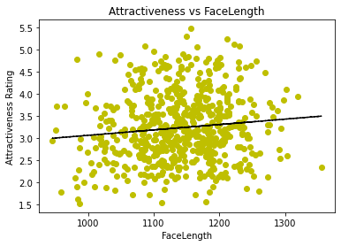

```python
scatter("FaceLength")
```

We can see that there is some linear correlation between the face length and attractiveness but not much. This makes sense because no one says that someone is beautiful just because their face is really long.

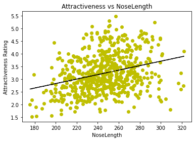

```python
scatter("NoseLength")
```

We can see some positive linear correlation between the nose length and attractiveness but again, a longer or shorter nose does not lead to higher attractiveness. A long nose on a small face could be overpowering, a small nose on a long face could seem too small.

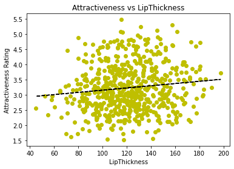

```python
scatter("LipThickness")
```

Again, we see some positive linear correlation between lip thickness and attractiveness but larger lips does not mean that someone is automatically attractive. At this point, we are starting to see that beauty is dependent on all the features but it is still difficult to pinpoint the exact combination of features that are significant. We can gain insight into this question by doing hypothesis testing on our model.

##### **Hypothesis Testing: F-Test of Overall Significance**

To test how well this model fits the data, and whether any of our predictors our significant, an overall F-test can be done. The null hypothesis for this test is that all of the coefficients associated with the predictors in the model are zero. This would mean that none of the predictors would help in explaining the variation in the attractiveness ratings. The alternative hypothesis is that at least one of these coefficients is not equal to zero. This would mean that at least one of the predictors would help in explaining a significant amount of the variation in the attractiveness rating. You can learn more about this kind of hypothesis test in this [link](https://statisticsbyjim.com/regression/interpret-f-test-overall-significance-regression/).

The F-statistic and its corresponding p-value for the model is given in the OLS summary. These measures are 8.313 and 3.22e-23 respectively. The decision rule in this hypothesis test is whether the p-value is less than alpha in which the standard value for alpha is 0.05. Since 3.22e-23 is less thant 0.05, we would reject the null hypothesis. This means that at least one predictor helps in explaining a significant amount of the variation in the attractiveness ratings. We can gain more insight into the specific predictors that help through partial F-tests.

##### **Hypothesis Testing: Partial F-Test**

The partial F-test is similar to the F-Test of overall significance in which it tests whether a group of predictors are significant. The null hypothesis and alternative hypothesis are the same in terms of testing whether all of the coefficients are zero or if at least one of them is not equal to zero. However, the different is that the partial test looks at a subset of all of the predictors in the model rather than all of them in terms of testing whether they are significant. This test is done as opposed to doing a series of parameter t-tests since there is a high probability for a type error to occur in at least one of these tests the more that are done in a row. More information about partial F-tests is given [here](https://www.statology.org/t-test-linear-regression/). In the code below, partial F-tests are done in terms of testing the predictors with the lowest t-statistics and corresponding p-values. The tests will be conducted at the 95% level of significance.

```python
#In the function below, threshold represents the minimum p-value that a
#predictor would have to be to be included in the partial F-test. This means
#that the higher p-values would be tested since these would be the predictors
#denoted as less significant compared to the others. In the code, we iterated
#through all of the predictors and kept an index of them such that we could
#get their p=value through the res.pvalues method. If this p-values was greater
#than or equal to the threshold, it would be included in the hypothesis. This
#means that it would be appended to the hypothesis string as "(predictor = 0),"
#and to the columns list. At the end, the hypothesis string would consist of a
#string with all of the predictors being stated to equal zero in which this
#string can then be inputted into the model results f_test method. From this
#method, the F-statistic and the corresponding p-value of the partial test
#will be printed. The columns list will hold of the predictors used in the
#test and will be returned.
def partial(threshold):
  numberOfAttributes = 22
  hypothesis = ""
  columns = []
  for name, attributeIndex in zip(X.columns, range(1, numberOfAttributes + 1)):
    if res.pvalues[attributeIndex] >= threshold:
      hypothesis += "(" + name + " = 0),"
      columns.append(name)
  hypothesis = hypothesis[:-1]
  f_test = res.f_test(hypothesis)
  print(hypothesis)
  print(f_test)
  return columns
```

We first did the test with a threshold of 0.025 since these would be the predictors that would have failed the predictor significance two-tailed t-test at a 95% significance level. Looking at the F-statistic and corresponding p-value, since the p-value is less than 0.05, we would reject the null hypothesis. This means that at least one of the predictors tested significantly explained the variation in the attractiveness ratings. Hence, we would be unable to deem the group of predictors as insignifcant.

```python
cols1 = partial(0.025)
```

```
(NoseWidth = 0),(EyeHeightR = 0),(EyeHeightL = 0),(EyeWidthR = 0),(EyeWidthL = 0),(FaceWidthCheeks = 0),(FaceWidthMouth = 0),(FaceWidthBZ = 0),(PupilTopAsymmetry = 0),(PupilLipR = 0),(MidbrowHairlineR = 0),(MidbrowHairlineL = 0),(CheekboneProminence = 0)
<F test: F=array([[2.25743761]]), p=0.006777136595209439, df_denom=574, df_num=13>
```

We can use a thereshold value of 0.05 to look at the predictors that failed their parameter t-test at a 90% level of significance to try again to see if we can deem a group of predictors as insignificant. Based on the results, the p-value is greater than 0.05 which means that the null hypothesis can be kept in which all of the coefficients of the predictors would be zero. Therefore, these predictors are all not significant in explaining the variation in the attractiveness ratings.

```python
cols2 = partial(0.05)
```

```
(EyeHeightR = 0),(EyeHeightL = 0),(EyeWidthR = 0),(EyeWidthL = 0),(FaceWidthMouth = 0),(FaceWidthBZ = 0),(PupilTopAsymmetry = 0),(PupilLipR = 0),(MidbrowHairlineR = 0),(MidbrowHairlineL = 0),(CheekboneProminence = 0)
<F test: F=array([[1.79458132]]), p=0.05175302464880025, df_denom=574, df_num=11>
```

The insignificant predictors from the hypothesis test are removed in which the resulting predictors would be the ones that were significant in explaining the attractiveness ratings. These predictors are printed below.

```python
significant = X.drop(cols2, axis=1)
for col in significant.columns:
  print(col)
```

```
LuminanceMedian
NoseWidth
NoseLength
LipThickness
FaceLength
FaceWidthCheeks
Forehead
UpperFaceLength2
PupilTopR
PupilLipAsymmetry
CheekboneHeight
```

##### **Summary of Insights for Linear Regression Method**

There is no general rule to addressing a single feature, ex. not everyone looks better with larger lips. Many rules vary across cultures in which each has their own set of beauty standards. This subjectivity can explain why we saw with our linear regression model that our predictors only explained 20% of the variation in the attractiveness ratings. Furthermore, the lack of general rules can explain why there was no clearly visible linear relationship could be seen in the scatterplots the facial features vs attractiveness ratings. Despite this, the assumptions of the linear model being met alongside the existence of significant predictors suggest that there are certain objective features of beauty.

# Part 2: DEEP LEARNING

Let's try a different approach this time: Given that we have identified some facial features that are significant in explaining the attractiveness ratings, we will attempt to train a model on the pictures associated with these ratings using Deep Learning to see if we can reach similar conclusions.

Firstly, as a note, it will take much more resources than we have access to in order to train a model from scratch. That is why for this project, we will be outsourcing a pre-initialized image recognition model by using Transfer Learning.

VGG16 is a pre-trained CNN transfer learning framework that has 138 million parameters. It contains a model, VGG_Face, that is tuned for facial recognition. More information about VGG16 can be found here: https://keras.io/api/applications/vgg/

We are going to need the attractiveness scores for each of the models, which brings us back to the deep_df sub-dataframe we sectioned out earlier in the project before we started to drop columns.

```python
deep_df.columns = ["Model", "Score"]
deep_df.head()
```

|  | Model | Score |
| --- | --- | --- |
| 1 | AF-200 | 4.111111 |
| 2 | AF-201 | 3.111111 |
| 3 | AF-202 | 3 |
| 4 | AF-203 | 3.275862 |
| 5 | AF-204 | 3.172414 |

Now that we have this shell, we need to adjust our data for use for deep learning. Since deep learning relies on reading images, we need to change the association from the person's identifier to the person's images. We can do this by searching through all the files along a given person's path and isolating the image files.

```python
import os
def getFileNames(model):
   files = []
   file_count = 0
   path = f"cfd/CFD Version 3.0/Images/CFD/{model}/"
   for r, d, f in os.walk(path):
      for file in f:
         if ('.jpg' in file) or ('.jpeg' in file) or ('.png' in file):
            files.append(file)
   return files

deep_df["files"] = deep_df.Model.apply(getFileNames)
deep_df.head()
```

|  | Model | Score | files |
| --- | --- | --- | --- |
| 1 | AF-200 | 4.111111 | [CFD-AF-200-228-N.jpg] |
| 2 | AF-201 | 3.111111 | [CFD-AF-201-060-N.jpg] |
| 3 | AF-202 | 3 | [CFD-AF-202-122-N.jpg] |
| 4 | AF-203 | 3.275862 | [CFD-AF-203-077-N.jpg] |
| 5 | AF-204 | 3.172414 | [CFD-AF-204-067-N.jpg] |

Now that we have the image files, we have to process them into the format that deep learning requires: Tensors of pixels. We first do this by getting all the pictures, mapping them to their Models, and then creating a dataframe with two columns, pixel-processed images and their attractiveness scores.

```python
unique_pictures = []

for index, person in deep_df.iterrows():
  for file in person.files:
    new_pic = []
    new_pic.append(person.Model)
    new_pic.append(file)
    new_pic.append(person.Score)
    unique_pictures.append(new_pic)

image_df = pd.DataFrame(unique_pictures, columns = ["person", "file", "score"])
image_df.head()
```

|  | person | file | score |
| --- | --- | --- | --- |
| 0 | AF-200 | CFD-AF-200-228-N.jpg | 4.111111 |
| 1 | AF-201 | CFD-AF-201-060-N.jpg | 3.111111 |
| 2 | AF-202 | CFD-AF-202-122-N.jpg | 3.000000 |
| 3 | AF-203 | CFD-AF-203-077-N.jpg | 3.275862 |
| 4 | AF-204 | CFD-AF-204-067-N.jpg | 3.172414 |

Now we have all the image files. All that's left to do is extract them into tensors of pixels.

```python
from tensorflow.keras.preprocessing.image import load_img, img_to_array
path = f"cfd/CFD Version 3.0/Images/CFD"

image_df["path"] = path + "/" + image_df['person'] + "/" + image_df['file']
image_df["pixels"] = image_df["path"].apply(lambda x: img_to_array(load_img(x, grayscale=False, target_size=(128, 128))).reshape(1, -1)[0])
image_df.head()
```

|  | person | file | score | path | pixels |
| --- | --- | --- | --- | --- | --- |
| 0 | AF-200 | CFD-AF-200-228-N.jpg | 4.111111 | cfd/CFD Version 3.0/Images/CFD/AF-200/CFD-AF-2... | [255.0, 255.0, 255.0, 255.0, 255.0, 255.0, 255... |
| 1 | AF-201 | CFD-AF-201-060-N.jpg | 3.111111 | cfd/CFD Version 3.0/Images/CFD/AF-201/CFD-AF-2... | [255.0, 255.0, 255.0, 255.0, 255.0, 255.0, 255... |
| 2 | AF-202 | CFD-AF-202-122-N.jpg | 3.000000 | cfd/CFD Version 3.0/Images/CFD/AF-202/CFD-AF-2... | [255.0, 255.0, 255.0, 255.0, 255.0, 255.0, 255... |
| 3 | AF-203 | CFD-AF-203-077-N.jpg | 3.275862 | cfd/CFD Version 3.0/Images/CFD/AF-203/CFD-AF-2... | [255.0, 255.0, 255.0, 255.0, 255.0, 255.0, 255... |
| 4 | AF-204 | CFD-AF-204-067-N.jpg | 3.172414 | cfd/CFD Version 3.0/Images/CFD/AF-204/CFD-AF-2... | [255.0, 255.0, 255.0, 255.0, 255.0, 255.0, 255... |

```python
image_df.shape
```

```
(1207, 5)
```

Now we have all our pixellated images, which need to be pre-processed into the format that VGG16 takes. To do so, we have to normalize the pixel values to be between 0 and 1, as well as expand them into 3d tensors instead of 1d arrays.

```python
features = []
pixels = image_df['pixels'].values
for i in range(0, pixels.shape[0]):
    features.append(pixels[i])

features = np.array(features)
features = features.reshape(features.shape[0], 128, 128, 3)

features = features / 255
```

Now we can part out the train and validation data using train_test_split.

```python
from sklearn.model_selection import train_test_split

train_x, val_x, train_y, val_y = train_test_split(features, image_df.score.values, test_size=0.33)
```

Now we can finally work on our VGG model!

```python
from tensorflow.keras.applications.vgg16 import VGG16
from tensorflow.keras.applications.vgg16 import preprocess_input

vgg_x = VGG16(
    include_top=False,
    weights="imagenet",
    input_tensor=None,
    input_shape=(128, 128, 3),
    pooling="max",
    classes=1000,
    classifier_activation="softmax",
)
```

Since we're not trying to re-train this model and only want to make it extrapolate based on what it already knows, we want to make the model untrainable except for a few of the final layers, which we readjust to make the model learn attractiveness.

```python
vgg_x.trainable = False
vgg_x.summary()
```

```
Model: "vgg16"
_________________________________________________________________
Layer (type)                 Output Shape              Param #
=================================================================
input_1 (InputLayer)         [(None, 128, 128, 3)]     0
_________________________________________________________________
block1_conv1 (Conv2D)        (None, 128, 128, 64)      1792
_________________________________________________________________
block1_conv2 (Conv2D)        (None, 128, 128, 64)      36928
_________________________________________________________________
block1_pool (MaxPooling2D)   (None, 64, 64, 64)        0
_________________________________________________________________
block2_conv1 (Conv2D)        (None, 64, 64, 128)       73856
_________________________________________________________________
block2_conv2 (Conv2D)        (None, 64, 64, 128)       147584
_________________________________________________________________
block2_pool (MaxPooling2D)   (None, 32, 32, 128)       0
_________________________________________________________________
block3_conv1 (Conv2D)        (None, 32, 32, 256)       295168
_________________________________________________________________
block3_conv2 (Conv2D)        (None, 32, 32, 256)       590080
_________________________________________________________________
block3_conv3 (Conv2D)        (None, 32, 32, 256)       590080
_________________________________________________________________
block3_pool (MaxPooling2D)   (None, 16, 16, 256)       0
_________________________________________________________________
block4_conv1 (Conv2D)        (None, 16, 16, 512)       1180160
_________________________________________________________________
block4_conv2 (Conv2D)        (None, 16, 16, 512)       2359808
_________________________________________________________________
block4_conv3 (Conv2D)        (None, 16, 16, 512)       2359808
_________________________________________________________________
block4_pool (MaxPooling2D)   (None, 8, 8, 512)         0
_________________________________________________________________
block5_conv1 (Conv2D)        (None, 8, 8, 512)         2359808
_________________________________________________________________
block5_conv2 (Conv2D)        (None, 8, 8, 512)         2359808
_________________________________________________________________
block5_conv3 (Conv2D)        (None, 8, 8, 512)         2359808
_________________________________________________________________
block5_pool (MaxPooling2D)   (None, 4, 4, 512)         0
_________________________________________________________________
global_max_pooling2d (Global (None, 512)               0
=================================================================
Total params: 14,714,688
Trainable params: 0
Non-trainable params: 14,714,688
_________________________________________________________________
```

```python
for layer in vgg_x.layers[-9:]:
  layer.trainable = True

import tensorflow as tf
from tensorflow.keras import Sequential, Model
from tensorflow.keras.layers import Dense, Flatten

vgg_output = Sequential()
vgg_output = Flatten()(vgg_x.layers[-4].output)
vgg_output = Dense(1)(vgg_output)

attractiveness_model = Model(inputs=vgg_x.input, outputs=vgg_output)
```

Since we're looking for a regression-based classification for the deep learning model, we are going to have to use Mean Squared Error as our loss function. As the optimization function, we will use ADAM to learn slightly faster than gradient descent.

For more information about ADAM and gradient descent updates, feel free to check out this source: https://machinelearningmastery.com/adam-optimization-algorithm-for-deep-learning/#:~:text=Adam%20is%20different%20to%20classical,does%20not%20change%20during%20training.

After compiling with the Adam optimizer, it's time to train the model. Our metric of choice is the validation loss, which is the performance of the model evaluated after every iteration over a subset of data to double-check its efficiency on non-training data.

Along the way, we save a checkpoint of the model, in case we want to load the weights again later.

Additionally, to save time and prevent overfitting, we stop the training once we notice that the validation loss metric has not improved after 10 iterations.

```python
from tensorflow.keras.optimizers import Adam
from tensorflow.keras.callbacks import ModelCheckpoint, EarlyStopping

attractiveness_model.compile(loss='mean_squared_error', optimizer=Adam())

checkpointer = ModelCheckpoint(filepath='attractiveness.hdf5', monitor = "val_loss", verbose=1, save_best_only=True, mode = 'auto')

earlyStop = EarlyStopping(monitor='val_loss', patience=10)

attractiveness_score = attractiveness_model.fit(train_x, train_y, epochs=1000, validation_data=(val_x, val_y), callbacks=[checkpointer, earlyStop], verbose=0)
```

```
Epoch 00001: val_loss improved from inf to 1.34408, saving model to attractiveness.hdf5

Epoch 00002: val_loss improved from 1.34408 to 0.65168, saving model to attractiveness.hdf5

Epoch 00003: val_loss improved from 0.65168 to 0.46223, saving model to attractiveness.hdf5

Epoch 00004: val_loss did not improve from 0.46223

Epoch 00005: val_loss did not improve from 0.46223

Epoch 00006: val_loss did not improve from 0.46223

Epoch 00007: val_loss did not improve from 0.46223

Epoch 00008: val_loss did not improve from 0.46223

Epoch 00009: val_loss did not improve from 0.46223

Epoch 00010: val_loss improved from 0.46223 to 0.45463, saving model to attractiveness.hdf5

Epoch 00011: val_loss did not improve from 0.45463

Epoch 00012: val_loss did not improve from 0.45463

Epoch 00013: val_loss improved from 0.45463 to 0.45411, saving model to attractiveness.hdf5

Epoch 00014: val_loss did not improve from 0.45411

Epoch 00015: val_loss improved from 0.45411 to 0.44826, saving model to attractiveness.hdf5

Epoch 00016: val_loss improved from 0.44826 to 0.44770, saving model to attractiveness.hdf5

Epoch 00017: val_loss did not improve from 0.44770

Epoch 00018: val_loss did not improve from 0.44770

Epoch 00019: val_loss did not improve from 0.44770

Epoch 00020: val_loss did not improve from 0.44770

```

[output cut: 124 more lines]

```
Epoch 00083: val_loss did not improve from 0.23352

Epoch 00084: val_loss did not improve from 0.23352

Epoch 00085: val_loss did not improve from 0.23352

Epoch 00086: val_loss did not improve from 0.23352

Epoch 00087: val_loss did not improve from 0.23352

Epoch 00088: val_loss did not improve from 0.23352

Epoch 00089: val_loss did not improve from 0.23352

Epoch 00090: val_loss did not improve from 0.23352
```

To see how good our model is doing, let's additionally plot models over our iterations to see the progression of our validation loss.

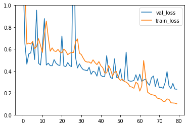

```python
best_iteration = np.argmin(attractiveness_score.history['val_loss'])+1
val_scores = attractiveness_score.history['val_loss'][0:best_iteration]
train_scores = attractiveness_score.history['loss'][0:best_iteration]

plt.plot(val_scores, label='val_loss')
plt.plot(train_scores, label='train_loss')
plt.legend(loc='upper right')
plt.ylim(0, 1)
plt.show()
```

```python
from sklearn.metrics import mean_absolute_error, mean_squared_error

predictions = attractiveness_model.predict(val_x)
actuals = val_y

perf = pd.DataFrame(actuals, columns = ["actuals"])
perf["predictions"] = predictions

print("pearson correlation: ",perf[['actuals', 'predictions']].corr(method ='pearson').values[0,1])
print("mae: ", mean_absolute_error(actuals, predictions))
print("rmse: ", np.sqrt(mean_squared_error(actuals, predictions)))
```

```
pearson correlation:  0.7519946014393237
mae:  0.39315341722414643
rmse:  0.5171771315110224
```

Having Pearson Correlation at .75 suggests that our model's prediction of attractiveness scores are relatively strongly correlated with the actual values.

MSE and RMSE are also low, with a RMSE of about 0.52 in particular suggesting a good accuracy of the model.

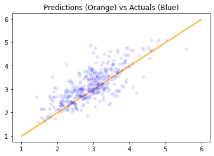

```python
min_limit = image_df.score.min(); max_limit = image_df.score.max()
best_predictions = []

for i in np.arange(int(min_limit), int(max_limit)+1, 0.01):
    best_predictions.append(round(i, 2))
plt.scatter(best_predictions, best_predictions, s=1, color = 'orange', alpha=0.5)
plt.scatter(predictions, actuals, s=20, alpha=0.1, color="blue")
plt.title("Predictions (Orange) vs Actuals (Blue)")
```

The data falls in the general neighborhood of line, not dissimilar to the trend that we saw earlier in the project. That is a sign that our deep learning model is working!

But it's not as fun to only look at the results and analytics of the model. Here, we also have some faces of some actual people (real and fictional). Let's test out the model by having it evaluate their faces.

```python
def rate(f):
  test_img =  img_to_array(load_img(f, grayscale=False, target_size=(128, 128))).reshape(1, -1)[0]
  test_features = test_img.reshape(1, 128, 128, 3)
  test_features = test_features / 255
  return attractiveness_model.predict(test_features)
```

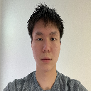

```python
(load_img("kevin_4.jpg", grayscale=False, target_size=(128, 128)))
```

```python
rate("kevin_4.jpg")
```

```
array([[2.6609306]], dtype=float32)
```

[figure not shown]

```python
load_img("minion.jfif", grayscale=False, target_size=(128, 128))
```

```python
rate("minion.jfif")
```

```
array([[2.5047348]], dtype=float32)
```

[figure not shown]

```python
load_img("zhongli.jfif", grayscale=False, target_size=(128, 128))
```

```python
rate("zhongli.jfif")
```

```
array([[2.9972014]], dtype=float32)
```

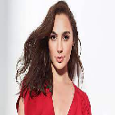

```python
load_img("celeb.jfif", grayscale=False, target_size=(128, 128))
```

```python
rate("celeb.jfif")
```

```
array([[3.0039928]], dtype=float32)
```

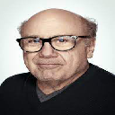

```python
load_img("dan.jfif", grayscale=False, target_size=(128, 128))
```

```python
rate("dan.jfif")
```

```
array([[1.8788564]], dtype=float32)
```

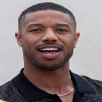

```python
load_img("jordan.jfif", grayscale=False, target_size=(128, 128))
```

```python
rate("jordan.jfif")
```

```
array([[2.8443375]], dtype=float32)
```

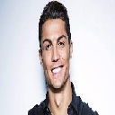

```python
load_img("ronaldo.jfif", grayscale=False, target_size=(128, 128))
```

```python
rate("ronaldo.jfif")
```

```
array([[4.3853784]], dtype=float32)
```

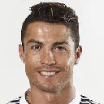

```python
load_img("ronaldo_1.jfif", grayscale=False, target_size=(128, 128))
```

```python
rate("ronaldo_1.jfif")
```

```
array([[3.7766047]], dtype=float32)
```

So either the model really loves Cristano Ronaldo or something isn't quite matching up with the model's evaluation on external data sources.

It seems like the model isn't the best at extrapolating "attractiveness scores" of models it hasn't seen before. Despite our best efforts, it seems that overfitting in this scenario is inevitable. First of all, we only trained the model on images of a specific format: No background, 1.44:1 aspect ratio, neutral expression, 50mm focal length.

The pictures of Ronaldo that happened to do well fit this criteria strongly: Centered on the page, more wide than tall, clipping the top of the shoulders.

Even if the model doesn't overfit on features, the restricted nature of the input data itself means that, in general, it doesn't do a good job of accurately rating input that doesn't exactly match. However, it seems like it might still be an estimator of *relative* attractiveness (Sorry Danny Devito).

## **CONCLUSION**

We created a deep learning model and a linear regression model to rate faces. We can say that there are objective measurements that contribute to a higher rating on the linear model. Features like face sizes, nose length, and lip thickness were significant in the linear model. The problem with the linear model is that it measures features independent of other features so there is no concept of balance on a face. Someone could have a nose that is "too large" for their face size but the linear model would not take that into account.

The deep learning model is interesting because there seems to be some merit to its ratings. The images we picked were from searching "*person name* head shot" on google images to find photos similar to the test data. It could be used to rate images that have the same format relative to each other. Most people would find Cristiano Ronaldo more attractive than Danny Devito (4 > 2). Interestingly, it can also be used to rate animated images of characters like Kevin the Minion and Zhong Li from Genshin Impact (3 > 2.5). Gal Gadot, Zhong Li, and Michael B. Jordan had ratings around a 3 and are considered conventionally attractive. These ratings seem reasonable to us.

It is remarkably difficult to rate attractiveness because the face is more than the sum of its parts. Faces are conventionally attractive when the features go together well. This is difficult for an algorithm to know but easy for a human to spot. Even then, it is hard for people to know why they find someone attractive. There are subjective preferences that change over time, such as beauty trends and cultural standards. On the other hand, there are features that are timeless. There is merit to the argument that beauty is objective. The linear model puts ratings on an individual's feature measurements and takes the sum of its parts. We do not know how the deep learning model rates but that seems to be the case with people in real life. Perhaps it takes the face's balance into account. What we know is that there is some merit to its predictions. After this, we still do not know what makes beautiful faces, we only know the ratings of these faces. Finding what makes faces attractive may be futile as everyone has their own unique preferences.